# classification du score crédit

#### Analyse des variables quantitatives

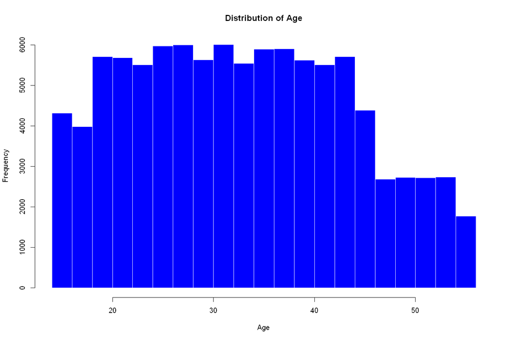

```r
hist(df$Age, main="Distribution of Age", xlab="Age",col="blue",border="white")
```

cet histogramme est un peu Asymétrique à droite: la majorité des valeurs se situent à gauche de la moyenne.Ainsi il ya une concentration d'age chez les jeunes

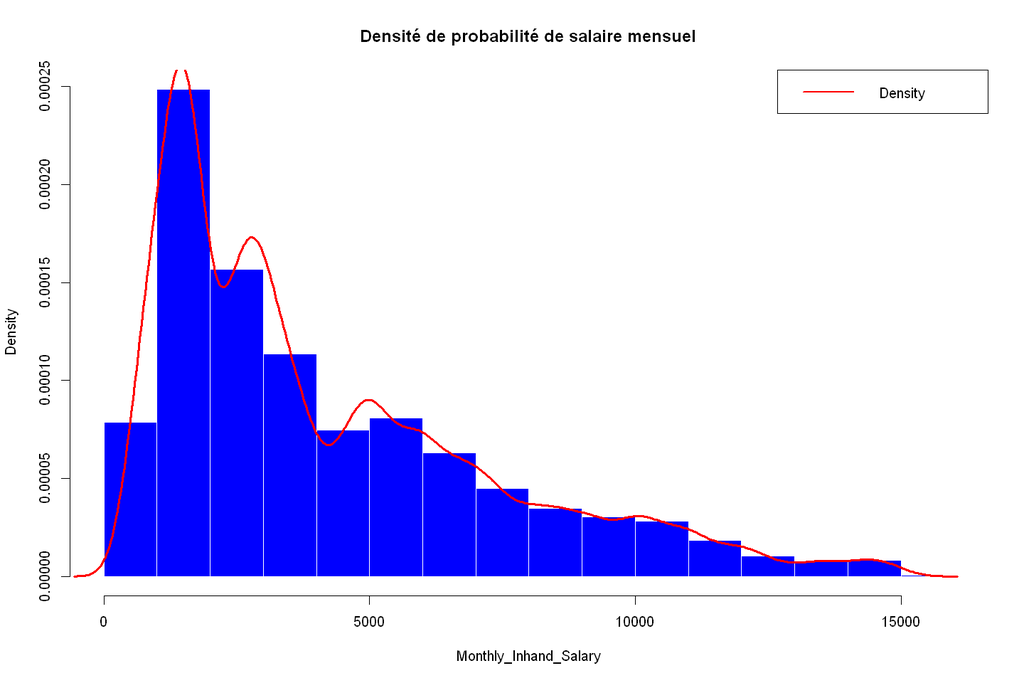

```r
hist(df$Monthly_Inhand_Salary, main="Densité de probabilité de salaire mensuel", xlab="Monthly_Inhand_Salary",col="blue",border="white",prob=T)
lines(density(df$Monthly_Inhand_Salary), lwd=3, col = "red" )
legend("topright", legend = "Density", col = "red", lwd = 2)
```

cet histogramme Asymétrique à droite: la majorité des valeurs se situent à gauche de la moyenne.Ainsi la mjorité des salaires sont inférieurs à 5000 dollars

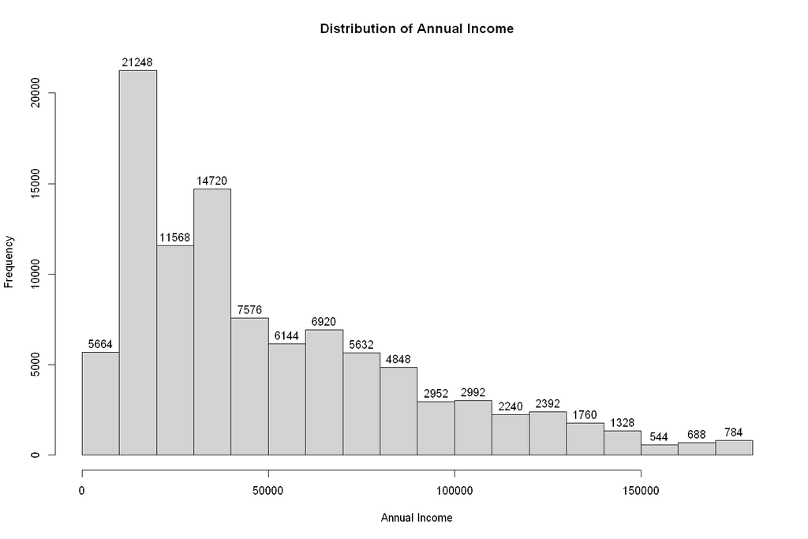

```r
hist(df$Annual_Income, main="Distribution of Annual Income", xlab="Annual Income",labels=T)
```

il ya 544+688+784=2016 personnes ayant un revenue annuel supérieur à 150000 dollars qui sont une minorité

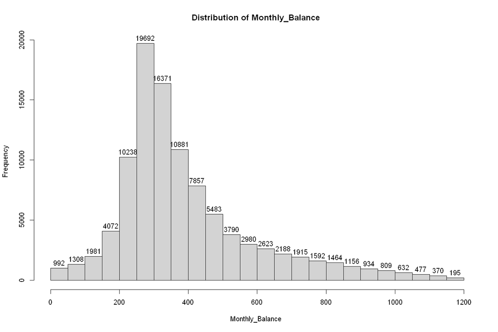

```r
hist(df$Monthly_Balance, main="Distribution of Monthly_Balance ", xlab="Monthly_Balance ",labels=T)
```

Unimodalité: L'histogramme présente une seule pointe ou mode, située approximativement autour 300 dollars. Cela indique que la distribution des soldes mensuels est concentrée autour de cette valeur moyenne.